# Dicom Detect with YOLOv7

Luiz Castiglioni

28/10/2022

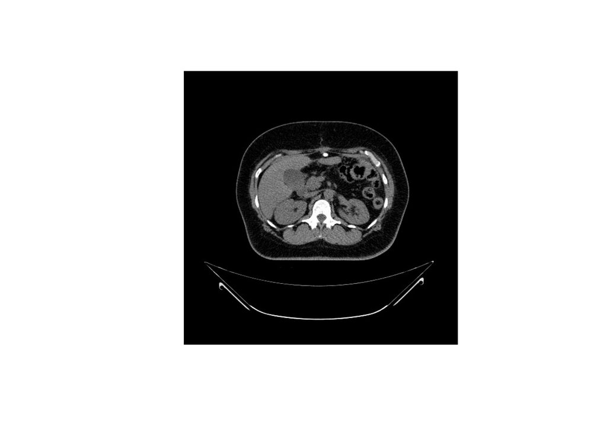

Trabalho de conclusão de curso do aluno Luiz Castiglioni.Pós-graduação MBA - Data Science and Analytics da USP / ESALQ. Trabalho desenvolvido em parceria com o departamento de AI da Escola Paulista de Medicina UNIFESP.

## Especificações do Projeto

### Data info

Tomographic images and Metadata of Medical Exams in DICOM Standards Format

### Links

- Dicom Medicine Standards https://www.dicomstandard.org/ai
- YOLO https://pjreddie.com/darknet/yolo/
- Github https://github.com/luizcast/DCM_TCC

### Arquivos do projeto

```r
list.files(include.dirs = TRUE)
```

```
##  [1] "5QUINTO_SCRIPT.R"
##  [2] "annot_clean.xlsx"
##  [3] "Anot_IMGS.R"
##  [4] "dcm_tools.Rproj"
##  [5] "exemplo_import_DICOM.R"
##  [6] "IMGs"
##  [7] "markdown_dicom_yolo_files"
##  [8] "markdown_dicom_yolo.docx"
##  [9] "markdown_dicom_yolo.html"
## [10] "markdown_dicom_yolo.pdf"
## [11] "markdown_dicom_yolo.Rmd"
## [12] "README.md"
## [13] "RESULTADOS"
## [14] "slides.odp"
## [15] "TCC_LuizCastiglioni_DSA_2022_FINAL.pdf"
## [16] "yolo_dicom_v1.pt"
```

### Configurações da Máquina

```bash
neofetch --stdout --disable theme wm theme icons packages uptime resolution de
```

[output not shown]

### Configurações do RStudio

```r
#RStudio 2022.07.2+576 "Spotted Wakerobin"
#Release 2022-09-06 for Ubuntu Bionic
version
```

```
##                _
## platform       x86_64-pc-linux-gnu
## arch           x86_64
## os             linux-gnu
## system         x86_64, linux-gnu
## status
## major          4
## minor          2.1
## year           2022
## month          06
## day            23
## svn rev        82513
## language       R
## version.string R version 4.2.1 (2022-06-23)
## nickname       Funny-Looking Kid
```

### Pacotes utilizados no projeto

- oro.dicom - https://cran.r-project.org/web/packages/oro.dicom/index.html
- dcmtk - https://dicom.offis.de/dcmtk.php.en
- tidyverse - https://www.tidyverse.org/
- tensorflow - https://www.tensorflow.org/
- keras - https://keras.io/

```r
library("keras")
library("tensorflow")
library("tidyverse")
library("oro.dicom")
library("dcmtk")
library("readxl")
```

## Reconhecendo Padrões em imagens de Tomografia de Abdómen no formato DICOM.

Foram selecionados 200 exames de tomografia de abdomen de 200 pacientes diferentes. Desses 200 exames foram geradas anotações pelo grupo de médicos e residentes da UNIFESP sobre a presença do órgão vesícula ou a presença do clipe cirúrgico em casos de pacientes que tiveram a vesícula retirada. Surgiram 4 classes:

- Pacientes com Vesícula Normal
- Pacientes com Vesícula Hipodistendida
- Pacientes sem Vesícula e com Clipe Cirúrgico
- Pacientes sem Vesícula e sem Clipe Cirúrgico

Destas anotações surgiu a tabela **annot_clean**

```r
read_excel("~/Desktop/USP/TCC/projeto_TCC/annot_clean.xlsx") %>% as_tibble() -> annot_clean
annot_clean
```

```
## # A tibble: 200 × 10
##    Acession Num…¹ Patie…² Corte…³ Corte…⁴ Hipod…⁵ Densi…⁶ Sem c…⁷ Arter…⁸ Portal
##             <dbl>   <dbl> <chr>   <chr>   <chr>   <chr>     <dbl>   <dbl>  <dbl>
##  1        5499993 3861927 Não se… Não se… S       Não se…       1       1      1
##  2        5493468  823083 Não se… Não se… C       Não se…       1       1      1
##  3        5480343 3586593 Não se… Não se… S       Não se…       0       1      1
##  4        5481425 2863787 Não se… Não se… C       Não se…       0       0      1
##  5        5480051 3880103 Não se… Não se… C       Não se…       0       0      1
##  6        5459110 3825619 Não se… Não se… S       Não se…       0       0      1
##  7        5465667 3132902 Não se… Não se… C       Não se…       1       1      1
##  8        5466142 3872936 Não se… Não se… C       Não se…       1       0      1
##  9        5435830 3227017 Não se… Não se… C       Não se…       1       1      1
## 10        5433748  870140 Não se… Não se… S       Não se…       0       0      1
## # … with 190 more rows, 1 more variable: Equilibrio <dbl>, and abbreviated
## #   variable names ¹`Acession Number`, ²`Patient ID`,
## #   ³`Corte INICIAL vesícula`, ⁴`Corte FINAL vesícula`,
## #   ⁵`Hipodistendida/Vesícula normal/Clipe/sem clipe (HVSC)`,
## #   ⁶`Densidade não habitual (sim=1, não=0)`,
## #   ⁷`Sem contraste (sim = 1; não = 0)`, ⁸Arterial
```

```r
colnames(annot_clean)
```

```
##  [1] "Acession Number"
##  [2] "Patient ID"
##  [3] "Corte INICIAL vesícula"
##  [4] "Corte FINAL vesícula"
##  [5] "Hipodistendida/Vesícula normal/Clipe/sem clipe (HVSC)"
##  [6] "Densidade não habitual (sim=1, não=0)"
##  [7] "Sem contraste (sim = 1; não = 0)"
##  [8] "Arterial"
##  [9] "Portal"
## [10] "Equilibrio"
```

### Tabela annot_Clean

```r
gsub(pattern = "Não se aplica", replacement = "NA",
     annot_clean$`Densidade não habitual (sim=1, não=0)`) ->
  annot_clean$`Densidade não habitual (sim=1, não=0)`
gsub(pattern = "Não se aplica", replacement = "NA",
     annot_clean$`Corte INICIAL vesícula`) ->
  annot_clean$`Corte INICIAL vesícula`
gsub(pattern = "Não se aplica", replacement = "NA",
     annot_clean$`Corte FINAL vesícula`) ->
  annot_clean$`Corte FINAL vesícula`
annot_clean$`Hipodistendida/Vesícula normal/Clipe/sem clipe (HVSC)` <-
  as.factor(annot_clean$`Hipodistendida/Vesícula normal/Clipe/sem clipe (HVSC)`)
annot_clean$`Corte FINAL vesícula` <-
  as.numeric(annot_clean$`Corte FINAL vesícula`)
annot_clean$`Corte INICIAL vesícula` <-
  as.numeric(annot_clean$`Corte INICIAL vesícula`)
annot_clean$`Densidade não habitual (sim=1, não=0)` <-
  as.numeric(annot_clean$`Densidade não habitual (sim=1, não=0)`)
annot_clean
```

```
## # A tibble: 200 × 10
##    Acession Num…¹ Patie…² Corte…³ Corte…⁴ Hipod…⁵ Densi…⁶ Sem c…⁷ Arter…⁸ Portal
##             <dbl>   <dbl>   <dbl>   <dbl> <fct>     <dbl>   <dbl>   <dbl>  <dbl>
##  1        5499993 3861927      NA      NA S            NA       1       1      1
##  2        5493468  823083      NA      NA C            NA       1       1      1
##  3        5480343 3586593      NA      NA S            NA       0       1      1
##  4        5481425 2863787      NA      NA C            NA       0       0      1
##  5        5480051 3880103      NA      NA C            NA       0       0      1
##  6        5459110 3825619      NA      NA S            NA       0       0      1
##  7        5465667 3132902      NA      NA C            NA       1       1      1
##  8        5466142 3872936      NA      NA C            NA       1       0      1
##  9        5435830 3227017      NA      NA C            NA       1       1      1
## 10        5433748  870140      NA      NA S            NA       0       0      1
## # … with 190 more rows, 1 more variable: Equilibrio <dbl>, and abbreviated
## #   variable names ¹`Acession Number`, ²`Patient ID`,
## #   ³`Corte INICIAL vesícula`, ⁴`Corte FINAL vesícula`,
## #   ⁵`Hipodistendida/Vesícula normal/Clipe/sem clipe (HVSC)`,
## #   ⁶`Densidade não habitual (sim=1, não=0)`,
## #   ⁷`Sem contraste (sim = 1; não = 0)`, ⁸Arterial
```

### Criando Dataset

```r
path = "/home/luiz/Desktop/DATA-SET_TESTE/"
list.files(path) %>%  as_tibble() -> array_arquivos_dicom_tratados
separate(array_arquivos_dicom_tratados, col = value, sep = "_", into = c("PatientID","SerieNumber","InstanceNumber")) -> index_dicom
index_dicom$InstanceNumber %>% str_sub(end=-5) -> index_dicom$InstanceNumber
bind_cols(array_arquivos_dicom_tratados,index_dicom) -> index_dicom
names(index_dicom) <- c("FileName","PatientID","SerieNumber","InstanceNumber")
          index_dicom$PatientID <- as.numeric(index_dicom$PatientID)
          index_dicom$SerieNumber <- as.numeric(index_dicom$SerieNumber)
          index_dicom$InstanceNumber <- as.numeric(index_dicom$InstanceNumber)
          glimpse(index_dicom)
```

```
## Rows: 153,435
## Columns: 4
## $ FileName       <chr> "0000121029_2_1.dcm", "0000121029_2_10.dcm", "000012102…
## $ PatientID      <dbl> 121029, 121029, 121029, 121029, 121029, 121029, 121029,…
## $ SerieNumber    <dbl> 2, 2, 2, 2, 2, 2, 2, 2, 2, 2, 2, 2, 2, 2, 2, 2, 2, 2, 2…
## $ InstanceNumber <dbl> 1, 10, 100, 101, 102, 103, 104, 105, 106, 107, 108, 109…
```

### Join das tabelas

```r
index_dicom %>% group_by(PatientID) %>%
  left_join(annot_clean, by = c("PatientID" = "Patient ID")) %>%
  ungroup() -> index_dicom
index_dicom$FilePath <- paste(path, index_dicom$FileName, sep='')
index_dicom %>% dplyr::select(1:9) -> base_tratada
base_tratada %>% dplyr::select(-5) -> base_tratada
base_tratada$FilePath <- paste(path, base_tratada$FileName, sep='')
base_tratada
```

```
## # A tibble: 165,794 × 9
##    FileName      Patie…¹ Serie…² Insta…³ Corte…⁴ Corte…⁵ Hipod…⁶ Densi…⁷ FileP…⁸
##    <chr>           <dbl>   <dbl>   <dbl>   <dbl>   <dbl> <fct>     <dbl> <chr>
##  1 0000121029_2…  121029       2       1      NA      NA S            NA /home/…
##  2 0000121029_2…  121029       2      10      NA      NA S            NA /home/…
##  3 0000121029_2…  121029       2     100      NA      NA S            NA /home/…
##  4 0000121029_2…  121029       2     101      NA      NA S            NA /home/…
##  5 0000121029_2…  121029       2     102      NA      NA S            NA /home/…
##  6 0000121029_2…  121029       2     103      NA      NA S            NA /home/…
##  7 0000121029_2…  121029       2     104      NA      NA S            NA /home/…
##  8 0000121029_2…  121029       2     105      NA      NA S            NA /home/…
##  9 0000121029_2…  121029       2     106      NA      NA S            NA /home/…
## 10 0000121029_2…  121029       2     107      NA      NA S            NA /home/…
## # … with 165,784 more rows, and abbreviated variable names ¹PatientID,
## #   ²SerieNumber, ³InstanceNumber, ⁴`Corte INICIAL vesícula`,
## #   ⁵`Corte FINAL vesícula`,
## #   ⁶`Hipodistendida/Vesícula normal/Clipe/sem clipe (HVSC)`,
## #   ⁷`Densidade não habitual (sim=1, não=0)`, ⁸FilePath
```

### Extraindo e Comparando Tabelas

```r
#TABELA FREQUENCIA annot_clean
table(annot_clean$`Hipodistendida/Vesícula normal/Clipe/sem clipe (HVSC)`)
```

```
##
##  C  H  S  V
## 73 10 27 90
```

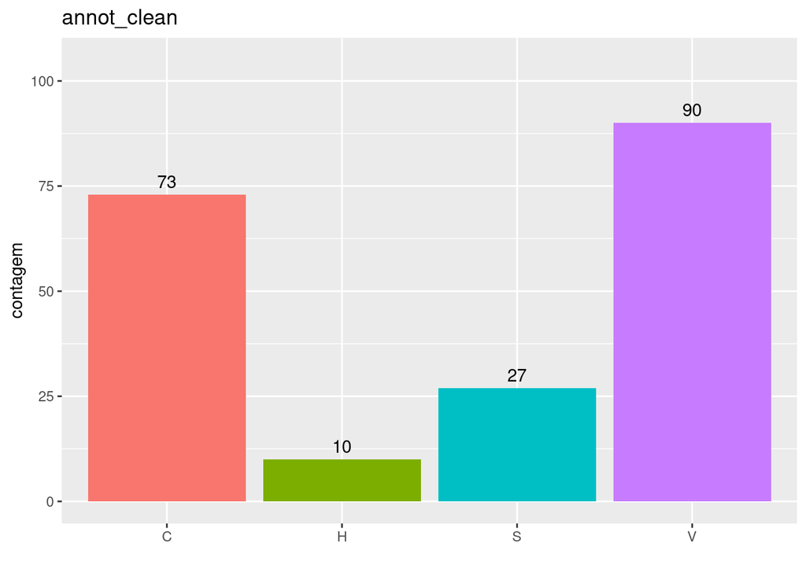

```r
annot_clean %>% ggplot(aes(x = `Hipodistendida/Vesícula normal/Clipe/sem clipe (HVSC)`)) + geom_bar(aes(fill = `Hipodistendida/Vesícula normal/Clipe/sem clipe (HVSC)`)) + ylim(0, 105) + geom_text(stat = 'count', aes(label = ..count..), vjust=-0.5) + ggtitle("annot_clean") + ylab("contagem") + xlab(label ='') + theme(legend.position = "none")
```

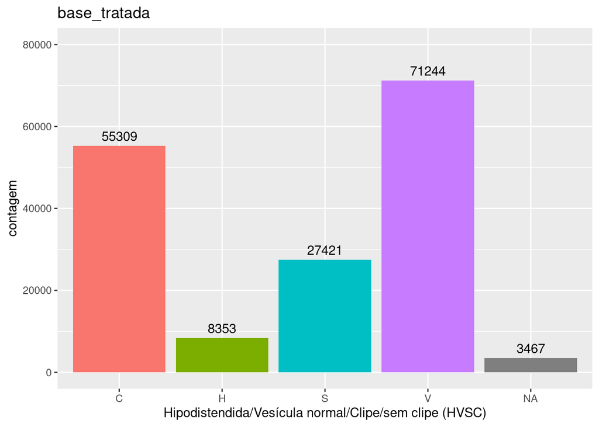

```r
#TABELA FREQUENCIA base_tratada
base_tratada %>% ggplot(aes(x = `Hipodistendida/Vesícula normal/Clipe/sem clipe (HVSC)`)) + geom_bar(aes(fill = `Hipodistendida/Vesícula normal/Clipe/sem clipe (HVSC)`)) + ylim(0, 80000) + geom_text(stat = 'count', aes(label = ..count..), vjust=-0.5) + ggtitle("base_tratada") + ylab("contagem") + theme(legend.position = "none")
```

```r
#N DE IMAGENS POR SERIENUMBER
base_tratada %>% group_by(PatientID) %>% count(SerieNumber) %>% ungroup(PatientID)
```

```
## # A tibble: 520 × 3
##    PatientID SerieNumber     n
##        <dbl>       <dbl> <int>
##  1    121029           2   150
##  2    121029           3   448
##  3    483240           4   285
##  4    483240           5   160
##  5    483240           6   478
##  6    548545           2   162
##  7    548545           3   484
##  8    604664           2   155
##  9    604664           8   461
## 10    604664           9   155
## # … with 510 more rows
```

```r
cat(nrow(filter(base_tratada,`Hipodistendida/Vesícula normal/Clipe/sem clipe (HVSC)` %in% c("H","V"))), "imagens de", paste(base_tratada %>% filter(`Hipodistendida/Vesícula normal/Clipe/sem clipe (HVSC)` %in% c("H","V")) %>% count(PatientID) %>% nrow()), "pacientes que TEM vesícula")
```

```
## 79597 imagens de 98 pacientes que TEM vesícula
```

```r
cat(nrow(filter(base_tratada,`Hipodistendida/Vesícula normal/Clipe/sem clipe (HVSC)` %in% c("S","C"))), "imagens de", paste(base_tratada %>% filter(`Hipodistendida/Vesícula normal/Clipe/sem clipe (HVSC)` %in% c("S","C")) %>% count(PatientID) %>% nrow()), "pacientes que NÃO TEM vesícula")
```

```
## 82730 imagens de 89 pacientes que NÃO TEM vesícula
```

```r
cat(nrow(filter(base_tratada,`Hipodistendida/Vesícula normal/Clipe/sem clipe (HVSC)` %in% c("V"))), "Imagens Vesícula Normal")
```

```
## 71244 Imagens Vesícula Normal
```

```r
cat(nrow(filter(base_tratada,`Hipodistendida/Vesícula normal/Clipe/sem clipe (HVSC)` %in% c("H"))), "Imagens Vesícula Hipodistendida")
```

```
## 8353 Imagens Vesícula Hipodistendida
```

```r
cat(nrow(filter(base_tratada,`Hipodistendida/Vesícula normal/Clipe/sem clipe (HVSC)` %in% c("C"))), "Imagens Clipe Cirúrgico")
```

```
## 55309 Imagens Clipe Cirúrgico
```

```r
cat(nrow(filter(base_tratada,`Hipodistendida/Vesícula normal/Clipe/sem clipe (HVSC)` %in% c("S"))), "Imagens sem Vesícula/Clipe")
```

```
## 27421 Imagens sem Vesícula/Clipe
```

```r
cat("Total de",nrow(base_tratada),"Imagens DICOM")
```

```
## Total de 165794 Imagens DICOM
```

```r
#TABELA COM AS IMAGENS DA VESICULA
base_tratada %>% filter(`Hipodistendida/Vesícula normal/Clipe/sem clipe (HVSC)`== "V") %>% mutate(posicao_interesse = ifelse(c(InstanceNumber >= `Corte INICIAL vesícula` & InstanceNumber <= `Corte FINAL vesícula`), 1, 0)) %>% filter(posicao_interesse == 1) %>% select(-posicao_interesse) -> base_frames_vesicula_normal
nrow(base_frames_vesicula_normal)
```

```
## [1] 4110
```

[output not shown]

[output not shown]

[output not shown]

[output not shown]

[output not shown]

[output not shown]

[output not shown]

```r
#TABELA COM AS IMAGENS DA VESICULA
base_tratada %>% filter(`Hipodistendida/Vesícula normal/Clipe/sem clipe (HVSC)`== "V") %>% mutate(posicao_interesse = ifelse(c(InstanceNumber >= `Corte INICIAL vesícula` & InstanceNumber <= `Corte FINAL vesícula`), 1, 0)) -> base_frames_vesicula_normal
base_frames_vesicula_normal %>% filter(posicao_interesse == 1) -> base_frames_vesicula_normal
glimpse(base_frames_vesicula_normal)
```

```
## Rows: 4,110
## Columns: 10
## $ FileName                                                <chr> "0000483240_4_…
## $ PatientID                                               <dbl> 483240, 483240…
## $ SerieNumber                                             <dbl> 4, 4, 4, 4, 4,…
## $ InstanceNumber                                          <dbl> 40, 41, 42, 43…
## $ `Corte INICIAL vesícula`                                <dbl> 40, 40, 40, 40…
## $ `Corte FINAL vesícula`                                  <dbl> 56, 56, 56, 56…
## $ `Hipodistendida/Vesícula normal/Clipe/sem clipe (HVSC)` <fct> V, V, V, V, V,…
## $ `Densidade não habitual (sim=1, não=0)`                 <dbl> 1, 1, 1, 1, 1,…
## $ FilePath                                                <chr> "/home/luiz/De…
## $ posicao_interesse                                       <dbl> 1, 1, 1, 1, 1,…
```